# Back-To-School Afghanistan Questionnaire Analysis

# Role model studies - Current Year PreQ

```r
#extracting all role model columns with gender and project sites
role_model_preq_currentyr<- PreQ.CurrYear %>% select(matches('Proj|Gende|Role'))

role_model_preq_currentyr[role_model_preq_currentyr==""]<- "Not Available"  # removing blanks with NA values
#role_model_preq_currentyr
```

```r
#### transforming role model column and calculating frequency count####

role_model_preq_currentyr_counts<- lapply(role_model_preq_currentyr,table)
#role_model_preq_currentyr_counts
```

```r
### converting to dataframe and reshape the structure of dataframe
role_model_freq_counts_reshape_currentyr<-as.data.frame(melt(role_model_preq_currentyr_counts)) #### reshaping the list to an required table

names(role_model_freq_counts_reshape_currentyr)[1:3]<-paste(c("Responses","Value","Questions"))


col_role_models<- c("Questions","Responses","Value")## column na,es of reshape dataframe
role_model_freq_counts_reshape_currentyr<-role_model_freq_counts_reshape_currentyr[,col_role_models] ## arranging column for role model dataframe

#role_model_freq_counts_reshape_currentyr
```

```r
## spreading the structure of dataframe
role_model_freq_counts_reshape_currentyr_table<-role_model_freq_counts_reshape_currentyr%>%spread(Responses,Value)
#role_model_freq_counts_reshape_currentyr_table
```

### Balloon plot of role model

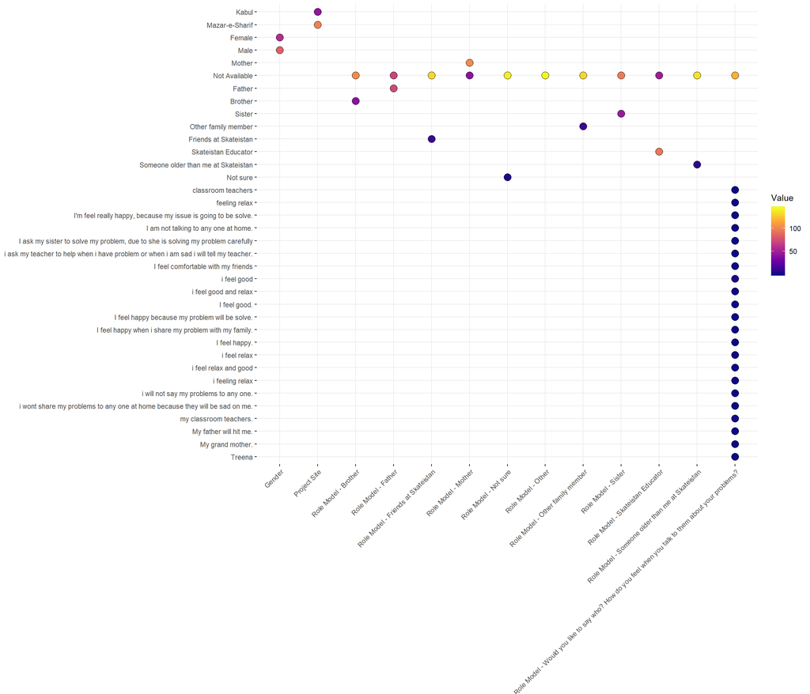

```r
rolemodel_freqcount_balloonplot_curryr<- ggballoonplot(role_model_freq_counts_reshape_currentyr, fill = "value", size = 4)+
  scale_fill_viridis_c(option = "C")
rolemodel_freqcount_balloonplot_curryr
```

## Heatmap

From this heatmap students mostly feel happy when they shated thie problems with their peers, teachers,family members. A more transparent system can build on top of it where student can speak freely that can results in removal of problem fear and netter communication among peers, parents and teachers

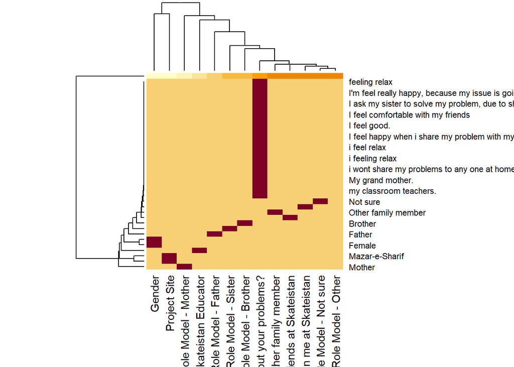

```r
role_model_freq_counts_reshape_heatmap_cy<-role_model_freq_counts_reshape_currentyr%>%spread(Questions,Value)

role_model_freq_counts_reshape_heatmap_cy<- as.data.frame(role_model_freq_counts_reshape_heatmap_cy)
role_model_freq_counts_reshape_heatmap_cy[is.na(role_model_freq_counts_reshape_heatmap_cy)] <- 0
role_model_freq_counts_reshape_heatmap2_cy <- as.matrix(role_model_freq_counts_reshape_heatmap_cy[, -1])
rownames(role_model_freq_counts_reshape_heatmap2_cy) <- role_model_freq_counts_reshape_heatmap_cy$Responses
heatmap(role_model_freq_counts_reshape_heatmap2_cy,margins = c(8,8))
```

## Correlation table

```r
role_model_correltion_cy<-role_model_freq_counts_reshape_heatmap2_cy
role_model_correltion_cy<-cor(role_model_correltion_cy)


#rownames(role_model_correltion_cy)<-colnames(role_model_correltion_cy)

role_model_correltion_cy<-as.data.frame(role_model_correltion_cy)
role_model_correltion_cy
```

|  | Gender | Project Site | Role Model - Brother | Role Model - Father | Role Model - Friends at Skateistan | Role Model - Mother | Role Model - Not sure | Role Model - Other | Role Model - Other family member | Role Model - Sister | Role Model - Skateistan Educator | Role Model - Someone older than me at Skateistan | Role Model - Would you like to say who? How do you feel when you talk to them about your problems? |
| --- | --- | --- | --- | --- | --- | --- | --- | --- | --- | --- | --- | --- | --- |
| Gender | 1.00000000 | -0.05369435 | -0.0528768 | -0.05782794 | -0.04390313 | -0.0528768 | -0.04147480 | -0.04030626 | -0.04390313 | -0.05446204 | -0.05494180 | -0.04267511 | -0.0490412 |
| Project Site | -0.05369435 | 1.00000000 | -0.0499322 | -0.05460762 | -0.04145826 | -0.0499322 | -0.03916515 | -0.03806169 | -0.04145826 | -0.05142916 | -0.05188221 | -0.04029862 | -0.0463102 |
| Role Model - Brother | -0.05287680 | -0.04993220 | 1.0000000 | 0.62897573 | 0.92286064 | 0.3113369 | 0.92699098 | 0.92768346 | 0.92286064 | 0.82783511 | 0.39658583 | 0.92543288 | 0.9248488 |
| Role Model - Father | -0.05782794 | -0.05460762 | 0.6289757 | 1.00000000 | 0.68184070 | 0.2179989 | 0.68572168 | 0.68661294 | 0.68184070 | 0.60686803 | 0.28161262 | 0.68416783 | 0.6817161 |
| Role Model - Friends at Skateistan | -0.04390313 | -0.04145826 | 0.9228606 | 0.68184070 | 1.00000000 | 0.3427768 | 0.99539246 | 0.99587527 | 0.99152542 | 0.89270776 | 0.43393594 | 0.99399548 | 0.9947579 |
| Role Model - Mother | -0.05287680 | -0.04993220 | 0.3113369 | 0.21799886 | 0.34277681 | 1.0000000 | 0.34578022 | 0.34670998 | 0.34277681 | 0.29904060 | 0.12710971 | 0.34448812 | 0.3406921 |
| Role Model - Not sure | -0.04147480 | -0.03916515 | 0.9269910 | 0.68572168 | 0.99539246 | 0.3457802 | 1.00000000 | 0.99959175 | 0.99539246 | 0.89684960 | 0.43720773 | 0.99781303 | 0.9988584 |
| Role Model - Other | -0.04030626 | -0.03806169 | 0.9276835 | 0.68661294 | 0.99587527 | 0.3467100 | 0.99959175 | 1.00000000 | 0.99587527 | 0.89758649 | 0.43814199 | 0.99826998 | 0.9994439 |
| Role Model - Other family member | -0.04390313 | -0.04145826 | 0.9228606 | 0.68184070 | 0.99152542 | 0.3427768 | 0.99539246 | 0.99587527 | 1.00000000 | 0.89270776 | 0.43393594 | 0.99399548 | 0.9947579 |
| Role Model - Sister | -0.05446204 | -0.05142916 | 0.8278351 | 0.60686803 | 0.89270776 | 0.2990406 | 0.89684960 | 0.89758649 | 0.89270776 | 1.00000000 | 0.38161526 | 0.89527130 | 0.8943496 |

[output cut: 3 more lines]

From this plot there might be an correlation present between the different subgroups of role model. As role model might have correlation as because those are our peer group like fatjer, mother,sister,friends, teachers which support each other. So if we needed to keep improve we needed to make a bond among these groups and can bring healthy intervation in students life.

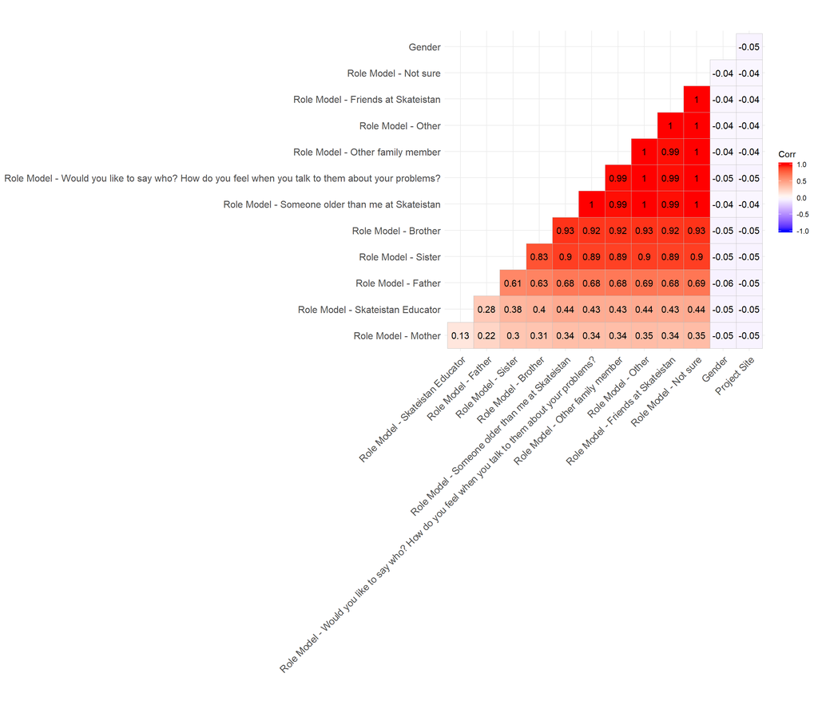

```r
ggcorrplot(role_model_correltion_cy,hc.order = TRUE,type = "lower",lab = TRUE)
```

## Sentiment Analysis #####

```r
Role_Model_who_says_curryr<- role_model_freq_counts_reshape_currentyr %>%
  filter(Questions=="Role Model - Would you like to say who? How do you feel when you talk to them about your problems?")

#Role_Model_who_says_curryr
```

```r
## transforming text from role model

Role_Model_who_says_curryr<-Role_Model_who_says_curryr[2]
role_vec_cy <- as.matrix(Role_Model_who_says_curryr)
role_vec_spl_cha_remove_cy<- gsub(".","",role_vec_cy,fixed=TRUE)
role_vec_spl_cha_remove_cy<- as.vector(role_vec_spl_cha_remove_cy)
#role_vec_spl_cha_remove_cy
```

# Wordcloud and wordplot

```r
## extract role answers  columns

##corpus

docs_cy<- Corpus(VectorSource(role_vec_spl_cha_remove_cy))

# Convert the text to lower case
docs_cy <- tm_map(docs_cy, content_transformer(tolower))
# Remove numbers
docs_cy <- tm_map(docs_cy, removeNumbers)
# Remove english common stopwords
docs_cy <- tm_map(docs_cy, removeWords, stopwords("english"))
# Remove your own stop word
# specify your stopwords as a character vector
# Remove punctuations
docs_cy <- tm_map(docs_cy, removePunctuation)
# Eliminate extra white spaces
docs_cy <- tm_map(docs_cy, stripWhitespace)
# Text stemming
docs_cy <- tm_map(docs_cy, stemDocument)
```

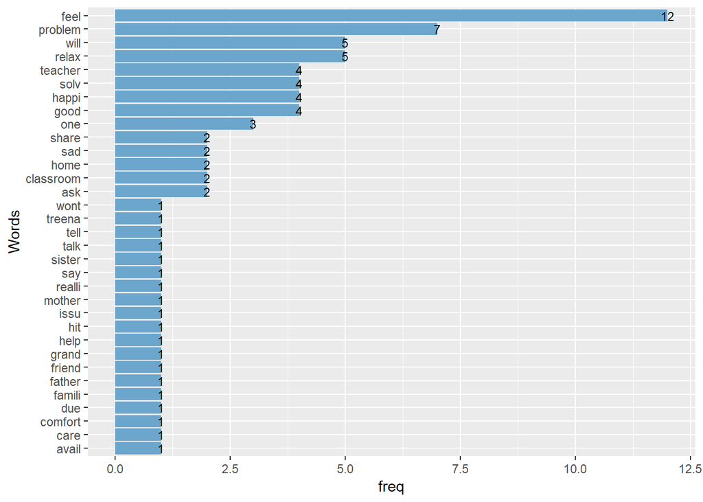

```r
dtm_cy <- TermDocumentMatrix(docs_cy)
m_cy <- as.matrix(dtm_cy)
v_cy <- sort(rowSums(m_cy),decreasing=TRUE)
d_cy <- data.frame(word = names(v_cy),freq=v_cy)
rownames(d_cy)<- NULL ## remove rownames from dataframe
d_cy<-d_cy %>% filter(word !="null")

d_cy %>%
    ggplot(aes(reorder(word,freq), freq)) +
      geom_col(fill = "skyblue3") +
      coord_flip() +geom_text(aes(label=freq),size=3)+
      labs(x = "Words")
```

```r
# p_cy<-ggplot(d_cy,aes(word,freq))+geom_bar(stat="identity")+geom_text(aes(label=freq),size=5)
# p_cy
#p_cy
#p_cy<-p+theme(axis.text.x = element_text(angle = 90, hjust = 1))
```

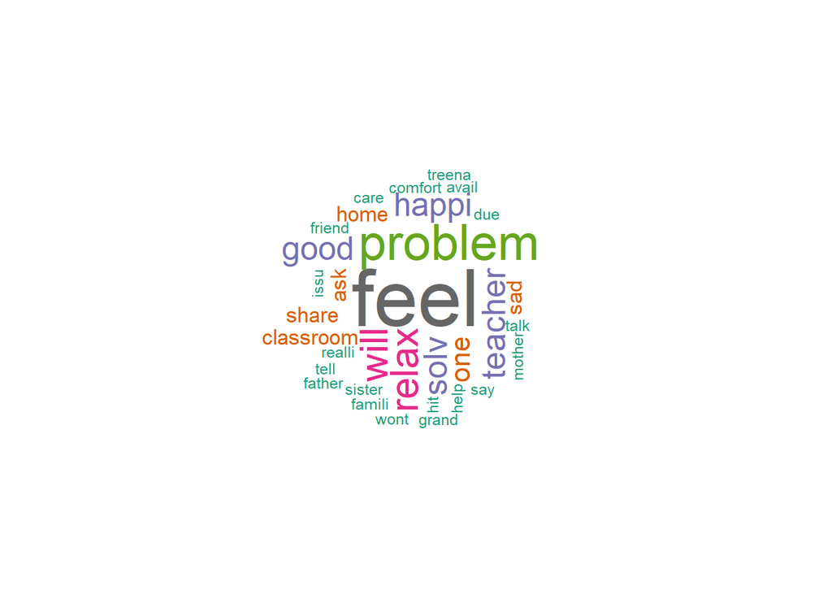

```r
word_rolemodel_cy<-wordcloud(words = d_cy$word, freq = d_cy$freq, min.freq = 1,max.words=200, random.order=FALSE, rot.per=0.35, colors=brewer.pal(8, "Dark2"))
```

From sentimental anaalysis of a particular group “Role model:would you like to say who” is of particular importance as from this analysis students wanted to express their thoughts to their peers. This make them to feel happy and ut solves their problem/ So they feel relax when they talk with their relatives, friends, classmates, teaches, parents.

# Role Model analysis - Previous Year PreQ

```r
#extracting all role model columns with gender and project sites
Freq_table_role_model<- PreQ.PrevYear %>%
  dplyr:: select("Project Site","Gender","Role Model - Father","Role Model - Brother/Sister","Role Model - Other family member","Role Model - Friends at Skateistan","Role Model - Skateistan Educator","Role Model - Someone older than me at Skateistan","Role Model - Other","Role Model - Would you like to say who?")
Freq_table_role_model[Freq_table_role_model==""]<- "Not Available"  # removing blanks with NA values
```

```r
#### transforming role model column and calculating frequency count####

role_model_freq_counts<- lapply(Freq_table_role_model,table)

### converting to dataframe and reshape the structure of dataframe
role_model_freq_counts_reshape<-as.data.frame(melt(role_model_freq_counts)) #### reshaping the list to an required table
col_role_model<- c("L1","Var1","value")## column na,es of reshape dataframe
role_model_freq_counts_reshape<- role_model_freq_counts_reshape[,col_role_model] ## arranging column for role model dataframe
#role_model_freq_counts_reshape

## spreading the structure of dataframe
role_model_freq_counts_reshape_table<-role_model_freq_counts_reshape%>%spread(Var1,value)
```

## Balloon Plot

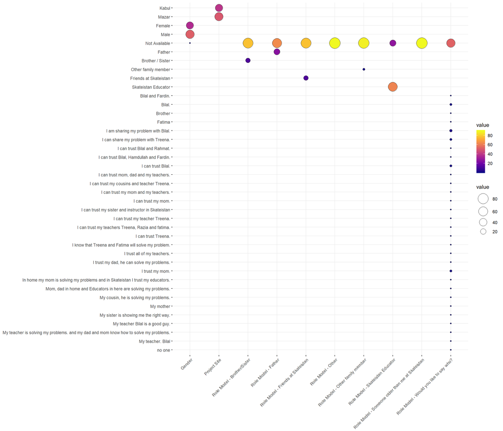

```r
### Balloon plot of role model
rolemodel_freqcount_balloonplot<- ggballoonplot(role_model_freq_counts_reshape, fill = "value")+
  scale_fill_viridis_c(option = "C")
rolemodel_freqcount_balloonplot
```

### Heatmap

Heatmap show the similar kind of trend from previous year as trust is an issue where students discuss their problems with their peer group. As this heatmap shows similar trend educators needed to pick up those communication channels and try to make it better. If trust is broken then the percentage of student might downfall, so to increase the flow a better environment of discussion is needed where everyone can grow without any fear.

[figure not shown]

```r
role_model_freq_counts_reshape_heatmap<-role_model_freq_counts_reshape%>%spread(L1,value)
role_model_freq_counts_reshape_heatmap<- as.data.frame(role_model_freq_counts_reshape_heatmap)
role_model_freq_counts_reshape_heatmap[is.na(role_model_freq_counts_reshape_heatmap)] <- 0
role_model_freq_counts_reshape_heatmap2 <- as.matrix(role_model_freq_counts_reshape_heatmap[, -1])
rownames(role_model_freq_counts_reshape_heatmap2) <- role_model_freq_counts_reshape_heatmap$Var1
heatmap(role_model_freq_counts_reshape_heatmap2)
```

### corelogram From this pre and post plot it is well established that role models having some sort of correlation which is an great sign for this program. As for motivation and for progress student always want inspiration and to overcome this way they learn from hardships their parents , teachers, freinds and relatives or other aspects has shown. This makes their morale boost and encourage in comtinula learning.

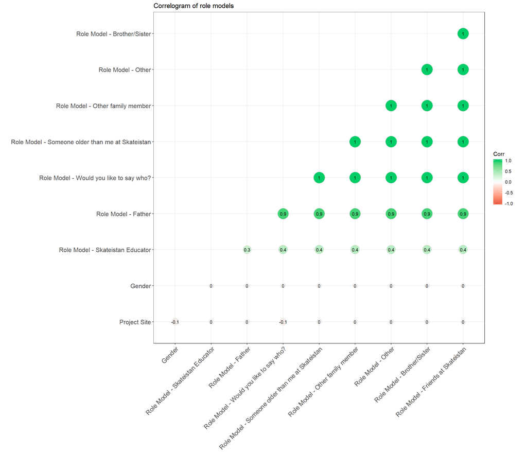

```r
role_model_correltion<-role_model_freq_counts_reshape_heatmap[,-1]
#rownames(role_model_correltion)<-colnames(role_model_correltion)
M<-round(cor(role_model_correltion),1)
ggcorrplot(M,hc.order = TRUE,type='lower',lab=TRUE,lab_size=3, method="circle",colors = c("tomato2", "white", "springgreen3"), ggtheme=theme_bw,title="Correlogram of role models")
```

#### Sentiment analysis

```r
#extracting all the Role Model - Would you like to say who? rows

role_model_who_says<- role_model_freq_counts_reshape %>%
  filter(L1=="Role Model - Would you like to say who?")

## transforming text from role model

role_model_who_says<-role_model_who_says[2]
role_vec <- as.matrix(role_model_who_says)
role_vec_spl_cha_remove<- gsub(".","",role_vec,fixed=TRUE)
role_vec_spl_cha_remove<- as.vector(role_vec_spl_cha_remove)


## extract role ansers  columns

docs<- Corpus(VectorSource(role_vec_spl_cha_remove))

# Convert the text to lower case
docs <- tm_map(docs, content_transformer(tolower))
# Remove numbers
docs <- tm_map(docs, removeNumbers)
# Remove english common stopwords
docs <- tm_map(docs, removeWords, stopwords("english"))
# Remove your own stop word
# specify your stopwords as a character vector
docs <- tm_map(docs, removeWords, c("blabla1", "blabla2"))
# Remove punctuations
docs <- tm_map(docs, removePunctuation)
# Eliminate extra white spaces
docs <- tm_map(docs, stripWhitespace)
```

[figure not shown]

```r
# Text stemming
# docs <- tm_map(docs, stemDocument)



dtm <- TermDocumentMatrix(docs)
m <- as.matrix(dtm)
v <- sort(rowSums(m),decreasing=TRUE)
d <- data.frame(word = names(v),freq=v)
rownames(d)<- NULL ## remove rownames from dataframe
d<-d %>% filter(word !="null")

d %>%
    ggplot(aes(reorder(word,freq), freq)) +
      geom_col(fill = "grey") +
      coord_flip() +geom_text(aes(label=freq),size=3)+
      labs(x = "words")
```

```r
# p<-ggplot(d,aes(word,freq))+geom_bar(stat="identity")+geom_text(aes(label=freq))
# p<-p+theme(axis.text.x = element_text(angle = 90, hjust = 1))
```

Most important thing that come up from the word cloud is word trust.Then family,teachers,friends,realtives. Trust plays a key role which shows whether student has bulit an relationship which makes them not to fear and tell their problems. As sample size is pretty small is hard to say but one thing is important from this outome student having trust in their peer group and which can accelerate well learning program. ### word plot and word cloud

[figure not shown]

```r
word_rolemodel<-wordcloud(words = d$word, freq = d$freq, min.freq = 1,max.words=100, random.order=FALSE, rot.per=0.35, colors=brewer.pal(8, "Dark2"))
```